# Basics of ANOVA and categorical data analysis in R

Michael Hallquist

15 Aug 2018

# 1 Introduction

The overall goal is to review ANOVA methods in R, as well as analyses of contingency tables (categorical data).

# 2 ANOVA

## 2.1 Simple between-subjects designs

For between-subjects designs, the `aov` function in R gives you most of what you’d need to compute standard ANOVA statistics. But it requires a fairly detailed understanding of sum of squares and typically assumes a balanced design. The `car::Anova` function takes things a bit further by allowing you to specify Type II or III sum of squares.

Consider the Moore 1971 dataset on conformity responses as a function of partner status (high/low) and level on an authoritarianism scale (highm medium, low). This is a between subjects design with 2 factors (2 x 3).

```r
mod <- lm(conformity ~ fcategory*partner.status, data=Moore)
Anova(mod, type="III")
```

|  | Sum Sq | Df | F value | Pr(>F) |
| --- | --- | --- | --- | --- |
| (Intercept) | 984.1 | 1 | 46.935 | 0.000 |
| fcategory | 89.7 | 2 | 2.138 | 0.131 |
| partner.status | 2.2 | 1 | 0.105 | 0.748 |
| fcategory:partner.status | 175.5 | 2 | 4.185 | 0.023 |
| Residuals | 817.8 | 39 | NA | NA |

Even better is the `afex` package, which handles most of the complexity of ANOVA designs.

```r
Moore$id <- 1:nrow(Moore)
res <- aov_ez(id="id", dv = "conformity", between = c("partner.status", "fcategory"), data=Moore)
```

```
## Contrasts set to contr.sum for the following variables: partner.status, fcategory
```

```r
print(res)
```

```
## Anova Table (Type 3 tests)
##
## Response: conformity
##                     Effect    df   MSE        F ges p.value
## 1           partner.status 1, 39 20.97 11.42 ** .23    .002
## 2                fcategory 2, 39 20.97     0.86 .04     .43
## 3 partner.status:fcategory 2, 39 20.97   4.18 * .18     .02
## ---
## Signif. codes:  0 '***' 0.001 '**' 0.01 '*' 0.05 '+' 0.1 ' ' 1
```

More detailed coverage of this example: https://cran.r-project.org/web/packages/afex/vignettes/afex_anova_example.html

## 2.2 User-friendly coverage of all ANOVA-type designs

In general, the `aov_ez` function from the `afex` package is an ideal tool for ANOVA analysis because it computes the expected ANOVA table, as well as effect size (generalized eta squared).

```r
str(sk2011.1)
```

```
## 'data.frame':    640 obs. of  9 variables:
##  $ id          : Factor w/ 40 levels "8","9","10","12",..: 3 3 3 3 3 3 3 3 3 3 ...
##  $ instruction : Factor w/ 2 levels "deductive","probabilistic": 2 2 2 2 2 2 2 2 2 2 ...
##  $ plausibility: Factor w/ 2 levels "plausible","implausible": 1 2 2 1 2 1 1 2 1 2 ...
##  $ inference   : Factor w/ 4 levels "MP","MT","AC",..: 4 2 1 3 4 2 1 3 4 2 ...
##  $ validity    : Factor w/ 2 levels "valid","invalid": 2 1 1 2 2 1 1 2 2 1 ...
##  $ what        : Factor w/ 2 levels "affirmation",..: 2 2 1 1 2 2 1 1 2 2 ...
##  $ type        : Factor w/ 2 levels "original","reversed": 2 2 2 2 1 1 1 1 2 2 ...
##  $ response    : int  100 60 94 70 100 99 98 49 82 50 ...
##  $ content     : Factor w/ 4 levels "C1","C2","C3",..: 1 1 1 1 2 2 2 2 3 3 ...
```

```r
a1 <- aov_ez("id", "response", sk2011.1, between = "instruction",
       within = c("inference", "plausibility"))
```

```
## Contrasts set to contr.sum for the following variables: instruction
```

```r
summary(a1)
```

```
##
## Univariate Type III Repeated-Measures ANOVA Assuming Sphericity
##
##                                     Sum Sq num Df Error SS den Df F value
## (Intercept)                        2004236      1    77042     38  988.56
## instruction                            622      1    77042     38    0.31
## inference                            14827      3    96988    114    5.81
## instruction:inference                15308      3    96988    114    6.00
## plausibility                         16046      1    17815     38   34.23
## instruction:plausibility              5001      1    17815     38   10.67
## inference:plausibility                2096      3    27779    114    2.87
## instruction:inference:plausibility    2911      3    27779    114    3.98
##                                     Pr(>F)
## (Intercept)                        < 2e-16 ***
## instruction                        0.58302
## inference                          0.00099 ***
## instruction:inference              0.00078 ***
## plausibility                       9.1e-07 ***
## instruction:plausibility           0.00232 **
## inference:plausibility             0.03970 *
## instruction:inference:plausibility 0.00971 **
## ---
## Signif. codes:  0 '***' 0.001 '**' 0.01 '*' 0.05 '.' 0.1 ' ' 1
##
##
## Mauchly Tests for Sphericity
##
##                                    Test statistic p-value
## inference                                   0.837  0.2582
## instruction:inference                       0.837  0.2582
## inference:plausibility                      0.652  0.0078
## instruction:inference:plausibility          0.652  0.0078
##
##
## Greenhouse-Geisser and Huynh-Feldt Corrections
##  for Departure from Sphericity
##
##                                    GG eps Pr(>F[GG])
## inference                           0.887     0.0016 **
## instruction:inference               0.887     0.0013 **
## inference:plausibility              0.764     0.0551 .
## instruction:inference:plausibility  0.764     0.0177 *
## ---
## Signif. codes:  0 '***' 0.001 '**' 0.01 '*' 0.05 '.' 0.1 ' ' 1
##
##                                    HF eps Pr(>F[HF])
## inference                           0.960   0.001185
## instruction:inference               0.960   0.000947
## inference:plausibility              0.816   0.051231
## instruction:inference:plausibility  0.816   0.015478
```

Pretty print out of ANOVA results

```r
knitr::kable(nice(a1))
```

| Effect | df | MSE | F | ges | p.value |
| --- | --- | --- | --- | --- | --- |
| instruction | 1, 38 | 2027.42 | 0.31 | .003 | .58 |
| inference | 2.66, 101.12 | 959.12 | 5.81 ** | .06 | .002 |
| instruction:inference | 2.66, 101.12 | 959.12 | 6.00 ** | .07 | .001 |
| plausibility | 1, 38 | 468.82 | 34.23 *** | .07 | <.0001 |
| instruction:plausibility | 1, 38 | 468.82 | 10.67 ** | .02 | .002 |
| inference:plausibility | 2.29, 87.11 | 318.91 | 2.87 + | .009 | .06 |
| instruction:inference:plausibility | 2.29, 87.11 | 318.91 | 3.98 * | .01 | .02 |

What about the estimated marginal means of the design?

```r
emmeans(a1, ~instruction * inference * plausibility)
```

```
##  instruction   inference plausibility emmean   SE  df lower.CL upper.CL
##  deductive     MP        plausible      99.5 6.01 190     87.6    111.3
##  probabilistic MP        plausible      95.3 6.01 190     83.4    107.2
##  deductive     MT        plausible      70.5 6.01 190     58.7     82.4
##  probabilistic MT        plausible      93.0 6.01 190     81.1    104.8
##  deductive     AC        plausible      66.9 6.01 190     55.1     78.8
##  probabilistic AC        plausible      90.5 6.01 190     78.7    102.4
##  deductive     DA        plausible      86.5 6.01 190     74.7     98.4
##  probabilistic DA        plausible      87.4 6.01 190     75.6     99.3
##  deductive     MP        implausible    95.1 6.01 190     83.2    107.0
##  probabilistic MP        implausible    60.2 6.01 190     48.3     72.0
##  deductive     MT        implausible    70.2 6.01 190     58.4     82.1
##  probabilistic MT        implausible    72.9 6.01 190     61.1     84.8
##  deductive     AC        implausible    56.0 6.01 190     44.2     67.9
##  probabilistic AC        implausible    64.1 6.01 190     52.3     76.0
##  deductive     DA        implausible    77.1 6.01 190     65.2     89.0
##  probabilistic DA        implausible    80.7 6.01 190     68.9     92.6
##
## Confidence level used: 0.95
```

What about the ‘main effects?’

```r
em1 <- emmeans(a1, ~inference)
```

```
## NOTE: Results may be misleading due to involvement in interactions
```

And pairwise difference among levels of inference validity?

```r
pairs(em1)
```

```
##  contrast estimate   SE  df t.ratio p.value
##  MP - MT     10.83 4.61 114   2.349  0.0933
##  MP - AC     18.10 4.61 114   3.925  0.0008
##  MP - DA      4.56 4.61 114   0.988  0.7566
##  MT - AC      7.27 4.61 114   1.576  0.3963
##  MT - DA     -6.28 4.61 114  -1.361  0.5266
##  AC - DA    -13.54 4.61 114  -2.937  0.0206
##
## Results are averaged over the levels of: instruction, plausibility
## P value adjustment: tukey method for comparing a family of 4 estimates
```

Note that emmeans plays well with the multcomp package, which provides a broader suite of multiple comparison corrections:

```r
summary(as.glht(pairs(em1)), test=adjusted("free"))
```

```
##
##   Simultaneous Tests for General Linear Hypotheses
##
## Linear Hypotheses:
##              Estimate Std. Error t value Pr(>|t|)
## MP - MT == 0    10.83       4.61    2.35  0.06892 .
## MP - AC == 0    18.10       4.61    3.92  0.00086 ***
## MP - DA == 0     4.56       4.61    0.99  0.32527
## MT - AC == 0     7.27       4.61    1.58  0.28168
## MT - DA == 0    -6.28       4.61   -1.36  0.29693
## AC - DA == 0   -13.54       4.61   -2.94  0.01813 *
## ---
## Signif. codes:  0 '***' 0.001 '**' 0.01 '*' 0.05 '.' 0.1 ' ' 1
## (Adjusted p values reported -- free method)
```

## 2.3 Plotting results of aov_ez

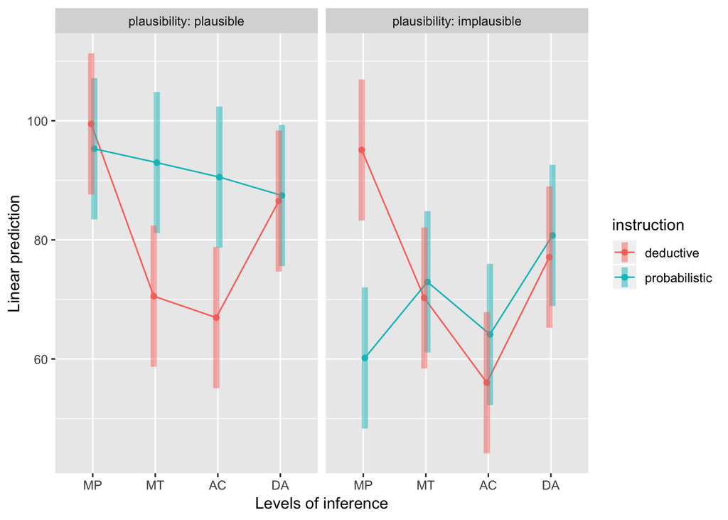

```r
emmip(a1, instruction ~ inference|plausibility, CIs = TRUE)
```

The `emmeans` package provides the `emmip` function, which is very useful for plotting the results of an `aov_ez` object.

# 3 Working with categorical data

The `vcd` and `vcdExtra packages are particulary handy for working with categorical data.

```r
data("Arthritis")

# attach(Arthritis)
# ###
# Treatment
# detach(Arthritis)

#table(Arthritis$Treatment, Arthritis$Sex)
with(Arthritis, table(Treatment, Sex))
```

```
##          Sex
## Treatment Female Male
##   Placebo     32   11
##   Treated     27   14
```

```r
tb <- with(Arthritis, table(Treatment, Sex))

tb["Placebo", "Female"]
```

```
## [1] 32
```

```r
with(Arthritis, table(Treatment))
```

```
## Treatment
## Placebo Treated
##      43      41
```

```r
#cell proportions
round(prop.table(tb), 3)
```

```
##          Sex
## Treatment Female  Male
##   Placebo  0.381 0.131
##   Treated  0.321 0.167
```

```r
#row proportions
round(prop.table(tb, 1), 3)
```

```
##          Sex
## Treatment Female  Male
##   Placebo  0.744 0.256
##   Treated  0.659 0.341
```

```r
#column proportions
round(prop.table(tb, 2), 3)
```

```
##          Sex
## Treatment Female  Male
##   Placebo  0.542 0.440
##   Treated  0.458 0.560
```

```r
#sum over rows
margin.table(tb, 1)
```

```
## Treatment
## Placebo Treated
##      43      41
```

```r
#add row margins
addmargins(tb, 1)
```

```
##          Sex
## Treatment Female Male
##   Placebo     32   11
##   Treated     27   14
##   Sum         59   25
```

```r
addmargins(tb, 2)
```

```
##          Sex
## Treatment Female Male Sum
##   Placebo     32   11  43
##   Treated     27   14  41
```

```r
addmargins(tb, c(1,2))
```

```
##          Sex
## Treatment Female Male Sum
##   Placebo     32   11  43
##   Treated     27   14  41
##   Sum         59   25  84
```

```r
#3-way table with formula syntax
#tb3 <- xtabs(~Treatment + Improved + Sex, Arthritis)
tb3 <- xtabs(~Treatment + Sex + Improved, Arthritis)
tb3
```

```
## , , Improved = None
##
##          Sex
## Treatment Female Male
##   Placebo     19   10
##   Treated      6    7
##
## , , Improved = Some
##
##          Sex
## Treatment Female Male
##   Placebo      7    0
##   Treated      5    2
##
## , , Improved = Marked
##
##          Sex
## Treatment Female Male
##   Placebo      6    1
##   Treated     16    5
```

```r
ftable(tb3)
```

```
##                  Improved None Some Marked
## Treatment Sex
## Placebo   Female            19    7      6
##           Male              10    0      1
## Treated   Female             6    5     16
##           Male               7    2      5
```

```r
## col ~ row
structable(Sex + Treatment ~  Improved, Arthritis)
```

```
##          Sex        Female            Male
##          Treatment Placebo Treated Placebo Treated
## Improved
## None                    19       6      10       7
## Some                     7       5       0       2
## Marked                   6      16       1       5
```

```r
xtable(xtabs(~ Sex + Treatment, Arthritis))
```

|  | Placebo | Treated |
| --- | --- | --- |
| Female | 32 | 27 |
| Male | 11 | 14 |

```r
#sum frequencies across sexes
freqdf <- Arthritis %>% count(Improved, Treatment) %>% ungroup()

#proportions
Arthritis %>% count(Improved, Treatment) %>% mutate(prop = prop.table(n))
```

| Improved | Treatment | n | prop |
| --- | --- | --- | --- |
| None | Placebo | 29 | 0.345 |
| None | Treated | 13 | 0.155 |
| Some | Placebo | 7 | 0.083 |
| Some | Treated | 7 | 0.083 |
| Marked | Placebo | 7 | 0.083 |
| Marked | Treated | 21 | 0.250 |

```r
#can obtain frequency tables from dplyr, too!
Arthritis %>%
  count(Improved, Treatment) %>%
  spread(Treatment, n)
```

| Improved | Placebo | Treated |
| --- | --- | --- |
| None | 29 | 13 |
| Some | 7 | 7 |
| Marked | 7 | 21 |

```r
Arthritis %>%
  count(Improved, Treatment, Sex) %>%
  spread(Treatment, n)
```

| Improved | Sex | Placebo | Treated |
| --- | --- | --- | --- |
| None | Female | 19 | 6 |
| None | Male | 10 | 7 |
| Some | Female | 7 | 5 |
| Some | Male | NA | 2 |
| Marked | Female | 6 | 16 |
| Marked | Male | 1 | 5 |

```r
#same as
xtabs(~Improved + Treatment, Arthritis)
```

```
##         Treatment
## Improved Placebo Treated
##   None        29      13
##   Some         7       7
##   Marked       7      21
```

```r
#and can collapse over factors in frequency form
freqdf %>% count(Improved, wt=n) #tell it to weight the counts by frequency variable n
```

| Improved | nn |
| --- | --- |
| None | 42 |
| Some | 14 |
| Marked | 28 |

```r
freqdf %>% group_by(Improved) %>% dplyr::summarize(freq=sum(n)) #more explicit syntax
```

| Improved | freq |
| --- | --- |
| None | 42 |
| Some | 14 |
| Marked | 28 |

```r
freqdf %>% count(Treatment, wt=n)
```

| Treatment | nn |
| --- | --- |
| Placebo | 43 |
| Treated | 41 |

```r
#2-way chi-square test
chisq.test(xtabs(~Treatment + Improved, Arthritis))
```

[output not shown]

```r
#association statistics
assocstats(xtabs(~Treatment + Improved, Arthritis))
```

```
##                     X^2 df  P(> X^2)
## Likelihood Ratio 13.530  2 0.0011536
## Pearson          13.055  2 0.0014626
##
## Phi-Coefficient   : NA
## Contingency Coeff.: 0.367
## Cramer's V        : 0.394
```

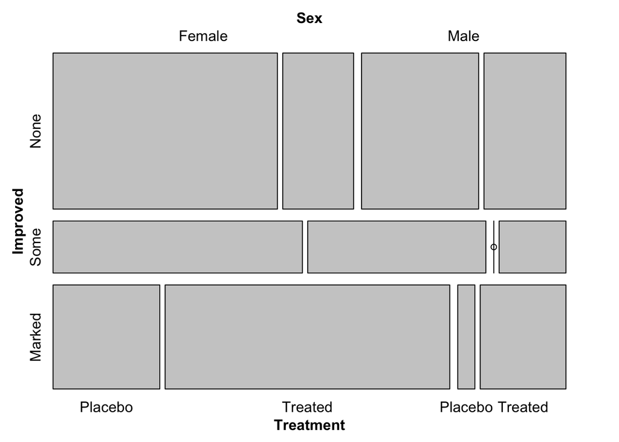

```r
#mosaic(structable(Treatment+Improved ~ Sex, Arthritis))
mosaic(structable(Sex+Treatment~Improved, Arthritis))
```

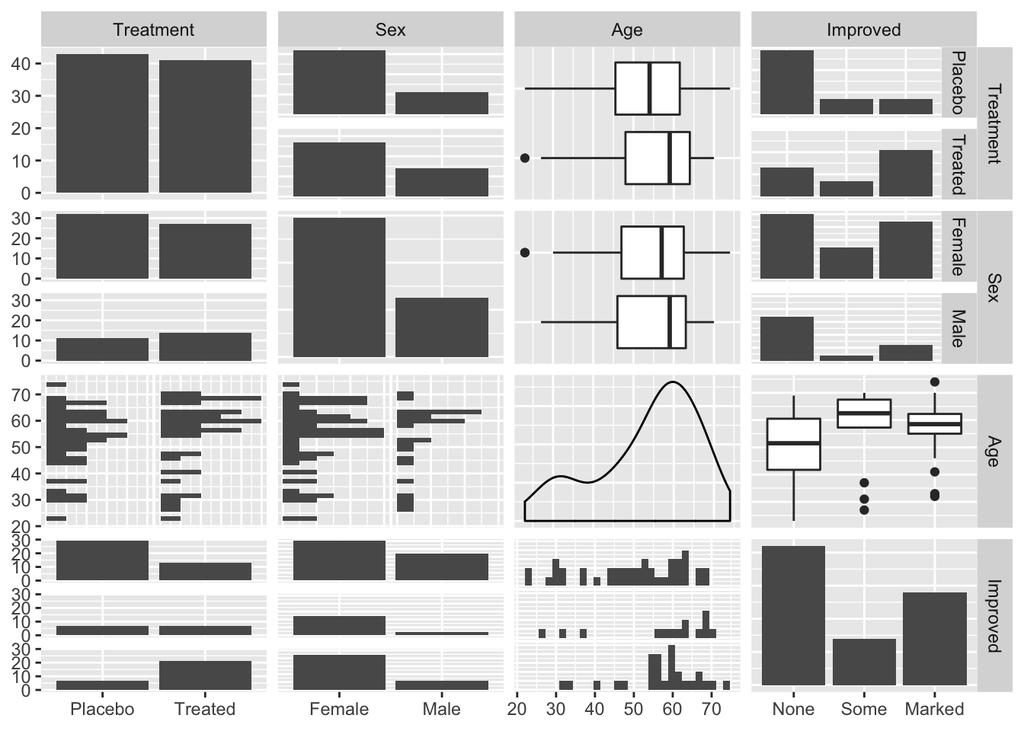

```r
ggpairs(dplyr::select(Arthritis, -ID))
```

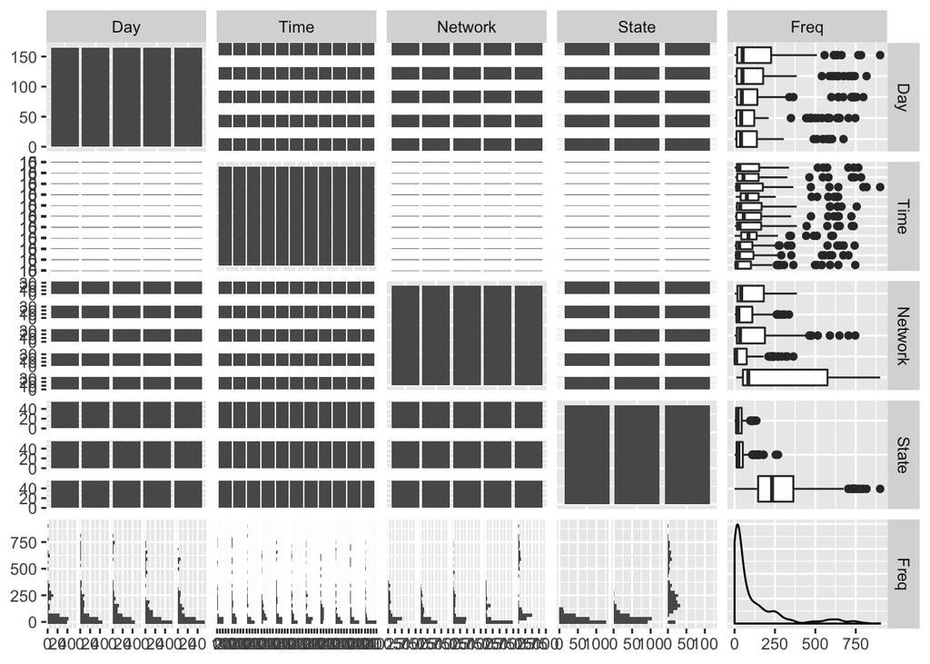

```r
tv.data<-read.table(system.file("doc","extdata","tv.dat",package="vcdExtra"))
TV <- xtabs(V5 ~ ., data=tv.data)

dimnames(TV) <- list(Day=c("Monday","Tuesday","Wednesday","Thursday","Friday"),
                     Time=c("8:00","8:15","8:30","8:45","9:00","9:15","9:30",
                            "9:45","10:00","10:15","10:30"),
                     Network=c("ABC","CBS","NBC","Fox","Other"),
                     State=c("Off","Switch","Persist"))

ggpairs(TV)
```

```r
TV <- TV[,,c("ABC", "CBS", "NBC"),]     # keep only ABC, CBS, NBC
TV <- TV[,,,"Persist"] #people who keep watching
structable(TV)
```

```
##                   Time 8:00 8:15 8:30 8:45 9:00 9:15 9:30 9:45 10:00 10:15 10:30
## Day       Network
## Monday    ABC           146  151  156   83  325  350  386  340   352   280   278
##           CBS           337  293  304  233  311  251  241  164   252   265   272
##           NBC           263  219  236  140  226  235  239  246   279   263   283
## Tuesday   ABC           244  181  231  205  385  283  345  192   329   351   364
##           CBS           173  180  184  109  218  235  256  250   274   263   261
##           NBC           315  254  280  241  370  214  195  111   188   190   210
## Wednesday ABC           233  161  194  156  339  264  279  140   237   228   203
##           CBS           158  126  207   59   98  103  122   86   109   105   110
##           NBC           134  146  166   66  194  230  264  143   274   289   306
## Thursday  ABC           174  183  197  181  187  198  211   86   110   122   117
##           CBS           196  185  195  104  106  116  116   47   102    84    84
##           NBC           515  463  472  477  590  473  446  349   649   705   747
## Friday    ABC           294  281  305  239  278  246  245  138   246   232   233
##           CBS           130  144  154   81  129  153  136  126   138   136   152
##           NBC           195  220  248  160  172  164  169   85   183   198   204
```

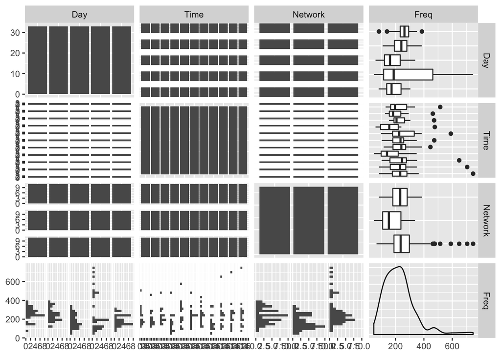

```r
ggpairs(TV)
```

```r
#more SPSS-like
CrossTable(TV[,,1],prop.t=FALSE,prop.r=FALSE,prop.c=FALSE)
```

```
##
##
##    Cell Contents
## |-------------------------|
## |                       N |
## | Chi-square contribution |
## |-------------------------|
##
##
## Total Observations in Table:  12894
##
##
##              | Time
##          Day |      8:00 |      8:15 |      8:30 |      8:45 |      9:00 |      9:15 |      9:30 |      9:45 |     10:00 |     10:15 |     10:30 | Row Total |
## -------------|-----------|-----------|-----------|-----------|-----------|-----------|-----------|-----------|-----------|-----------|-----------|-----------|
##       Monday |       146 |       151 |       156 |        83 |       325 |       350 |       386 |       340 |       352 |       280 |       278 |      2847 |
##              |    37.381 |    17.211 |    28.897 |    60.883 |     0.258 |     9.814 |    11.993 |   102.156 |    17.769 |     0.553 |     0.758 |           |
## -------------|-----------|-----------|-----------|-----------|-----------|-----------|-----------|-----------|-----------|-----------|-----------|-----------|
##      Tuesday |       244 |       181 |       231 |       205 |       385 |       283 |       345 |       192 |       329 |       351 |       364 |      3110 |
##              |     1.393 |    10.755 |     3.495 |     0.055 |     1.077 |     5.058 |     0.209 |     2.690 |     1.534 |    11.668 |    19.918 |           |
## -------------|-----------|-----------|-----------|-----------|-----------|-----------|-----------|-----------|-----------|-----------|-----------|-----------|
##    Wednesday |       233 |       161 |       194 |       156 |       339 |       264 |       279 |       140 |       237 |       228 |       203 |      2434 |
##              |     3.553 |     2.138 |     0.533 |     0.309 |     9.904 |     0.466 |     0.019 |     5.020 |     0.051 |     0.004 |     2.260 |           |
## -------------|-----------|-----------|-----------|-----------|-----------|-----------|-----------|-----------|-----------|-----------|-----------|-----------|
##     Thursday |       174 |       183 |       197 |       181 |       187 |       198 |       211 |        86 |       110 |       122 |       117 |      1766 |
##              |     4.041 |    20.571 |    15.969 |    33.183 |     1.999 |     1.118 |     0.519 |    10.987 |    23.835 |    11.725 |    13.308 |           |
## -------------|-----------|-----------|-----------|-----------|-----------|-----------|-----------|-----------|-----------|-----------|-----------|-----------|
##       Friday |       294 |       281 |       305 |       239 |       278 |       246 |       245 |       138 |       246 |       232 |       233 |      2737 |
##              |    16.821 |    29.841 |    24.542 |    16.855 |     5.854 |     5.249 |    14.077 |    14.323 |     2.207 |     2.522 |     1.683 |           |
## -------------|-----------|-----------|-----------|-----------|-----------|-----------|-----------|-----------|-----------|-----------|-----------|-----------|
## Column Total |      1091 |       957 |      1083 |       864 |      1514 |      1341 |      1466 |       896 |      1274 |      1213 |      1195 |     12894 |
## -------------|-----------|-----------|-----------|-----------|-----------|-----------|-----------|-----------|-----------|-----------|-----------|-----------|
##
##
```

## 3.1 Logistic regression

We won’t cover this here, but check out this nice tutorial: https://stats.idre.ucla.edu/r/dae/logit-regression/

## 3.2 Multinomial regression

Likewise, see this: https://stats.idre.ucla.edu/r/dae/multinomial-logistic-regression/